# Supervised Learning : Exploring Boosting, Bagging and Stacking Algorithms for Ensemble Learning

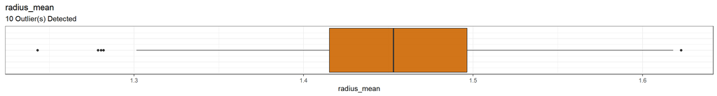

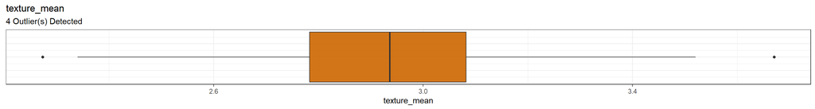

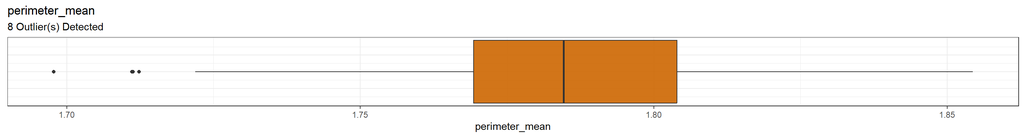

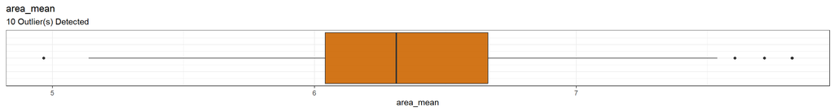

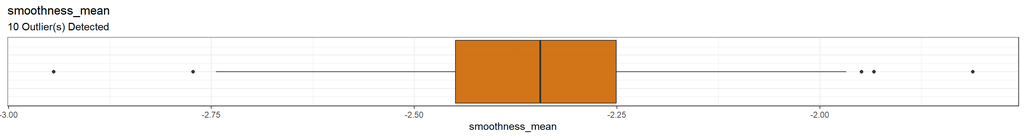

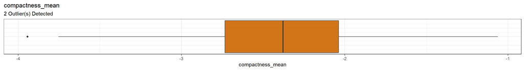

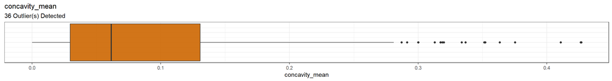

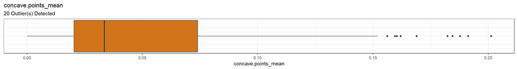

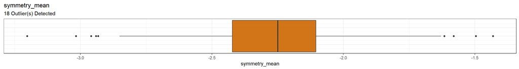

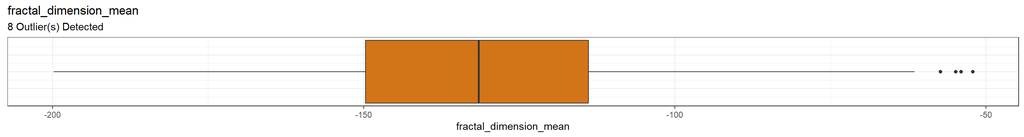

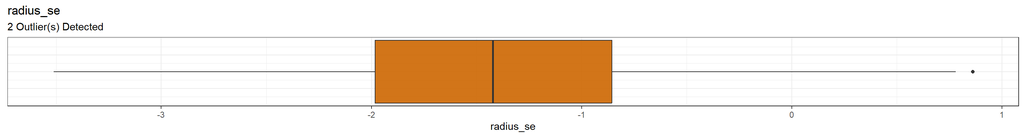

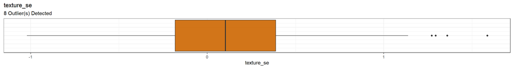

[18 more figures not shown]

```r
##################################
# Identifying outliers for the numeric predictors
##################################
OutlierCountList <- c()

for (i in 1:ncol(DPA_BoxCoxTransformed)) {
  Outliers <- boxplot.stats(DPA_BoxCoxTransformed[,i])$out
  OutlierCount <- length(Outliers)
  OutlierCountList <- append(OutlierCountList,OutlierCount)
  OutlierIndices <- which(DPA_BoxCoxTransformed[,i] %in% c(Outliers))
  print(
  ggplot(DPA_BoxCoxTransformed, aes(x=DPA_BoxCoxTransformed[,i])) +
  geom_boxplot() +
  theme_bw() +
  theme(axis.text.y=element_blank(),
        axis.ticks.y=element_blank()) +
  xlab(names(DPA_BoxCoxTransformed)[i]) +
  labs(title=names(DPA_BoxCoxTransformed)[i],
       subtitle=paste0(OutlierCount, " Outlier(s) Detected")))
}
```

```r
DPA_BoxCoxTransformed$diagnosis <- DPA[,c("diagnosis")]
```

### 1.3.6 Pre-Processed Dataset

**[A]** A total of 12 predictors were removed prior to data exploration and modelling due to issues identified during data preprocessing.  
**[A.1]** concavity_se = Low variance and high skewness  
**[A.2]** perimeter_worst = High correlation with radius_worst, area_worst, perimeter_mean, radius_mean and area_mean  
**[A.3]** radius_worst = High correlation with perimeter_worst, area_worst, radius_mean, perimeter_mean and area_mean  
**[A.4]** perimeter_mean = High correlation with radius_mean, area_mean, perimeter_worst and radius_worst  
**[A.5]** area_worst = High correlation with radius_worst, perimeter_worst and area_mean  
**[A.6]** radius_mean = High correlation with perimeter_mean, area_mean, radius_worst and perimeter_worst .  
**[A.7]** perimeter_se = High correlation with radius_se  
**[A.8]** area_se = High correlation with radius_se  
**[A.9]** concavity_mean = High outlier count even after shape transformation  
**[A.10]** concave.points_mean = High outlier count even after shape transformation  
**[A.11]** concave.points_se = High outlier count even after shape transformation  
**[A.12]** concavity_worst = High outlier count even after shape transformation  
**[B]** The preprocessed tabular dataset was comprised of 1138 observations and 19 variables (including 1 response and 18 predictors).  
**[B.1]** 1138 rows (observations)  
**[B.2]** 19 columns (variables)  
**[B.2.1]** 1/19 response = diagnosis (factor)  
**[B.2.2]** 18/19 predictors = 18/18 numeric  
**[B.2.2.1]** texture_mean (numeric)  
**[B.2.2.2]** area_mean (numeric)  
**[B.2.2.3]** smoothness_mean (numeric)  
**[B.2.2.4]** compactness_mean (numeric)  
**[B.2.2.5]** symmetry_mean (numeric)  
**[B.2.2.6]** fractal_dimension_mean (numeric)  
**[B.2.2.7]** radius_se (numeric)  
**[B.2.2.8]** texture_se (numeric)  
**[B.2.2.9]** smoothness_se (numeric)  
**[B.2.2.10]** compactness_se (numeric)  
**[B.2.2.11]** symmetry_se (numeric)  
**[B.2.2.12]** fractal_dimension_se (numeric)  
**[B.2.2.13]** texture_worst (numeric)  
**[B.2.2.14]** smoothness_worst (numeric)  
**[B.2.2.15]** compactness_worst (numeric)  
**[B.2.2.16]** concave.points_worst (numeric)  
**[B.2.2.17]** symmetry_worst (numeric)  
**[B.2.2.18]** fractal_dimension_worst (numeric)

**Code Chunk | Output**

```r
##################################
# Creating the pre-modelling
# train set
##################################
PMA <- DPA_BoxCoxTransformed[,!names(DPA_BoxCoxTransformed) %in% c("concavity_se",
                                                                   "perimeter_worst",
                                                                   "radius_worst",
                                                                   "perimeter_mean",
                                                                   "area_worst",
                                                                   "radius_mean",
                                                                   "perimeter_se",
                                                                   "area_se",
                                                                   "concavity_mean",
                                                                   "concave.points_mean",
                                                                   "concave.points_se",
                                                                   "concavity_worst")]

##################################
# Gathering descriptive statistics
##################################
(PMA_Skimmed <- skim(PMA))
```

Data summary

| Name | PMA |
| --- | --- |
| Number of rows | 1138 |
| Number of columns | 19 |
| _______________________ |  |
| Column type frequency: |  |
| factor | 1 |
| numeric | 18 |
| ________________________ |  |
| Group variables | None |

**Variable type: factor**

| skim_variable | n_missing | complete_rate | ordered | n_unique | top_counts |
| --- | --- | --- | --- | --- | --- |
| diagnosis | 0 | 1 | FALSE | 2 | B: 714, M: 424 |

**Variable type: numeric**

| skim_variable | n_missing | complete_rate | mean | sd | p0 | p25 | p50 | p75 | p100 | hist |
| --- | --- | --- | --- | --- | --- | --- | --- | --- | --- | --- |
| texture_mean | 0 | 1 | 2.94 | 0.22 | 2.27 | 2.78 | 2.94 | 3.08 | 3.67 | ▁▅▇▃▁ |
| area_mean | 0 | 1 | 6.36 | 0.48 | 4.97 | 6.04 | 6.31 | 6.66 | 7.82 | ▁▅▇▃▁ |
| smoothness_mean | 0 | 1 | -2.35 | 0.15 | -2.94 | -2.45 | -2.34 | -2.25 | -1.81 | ▁▂▇▃▁ |
| compactness_mean | 0 | 1 | -2.38 | 0.49 | -3.94 | -2.73 | -2.38 | -2.04 | -1.06 | ▁▅▇▇▂ |
| symmetry_mean | 0 | 1 | -2.26 | 0.25 | -3.20 | -2.42 | -2.25 | -2.10 | -1.43 | ▁▂▇▅▁ |
| fractal_dimension_mean | 0 | 1 | -130.58 | 26.03 | -199.82 | -149.68 | -131.52 | -113.87 | -52.16 | ▁▆▇▃▁ |
| radius_se | 0 | 1 | -1.42 | 0.81 | -3.51 | -1.98 | -1.42 | -0.86 | 0.86 | ▁▆▇▅▁ |
| texture_se | 0 | 1 | 0.10 | 0.43 | -1.02 | -0.18 | 0.10 | 0.39 | 1.59 | ▂▆▇▂▁ |
| smoothness_se | 0 | 1 | -11.83 | 1.66 | -19.20 | -12.84 | -11.85 | -10.78 | -6.11 | ▁▂▇▅▁ |
| compactness_se | 0 | 1 | -3.88 | 0.65 | -6.10 | -4.34 | -3.89 | -3.43 | -2.00 | ▁▃▇▆▁ |
| symmetry_se | 0 | 1 | -16.51 | 3.52 | -28.80 | -18.91 | -16.46 | -14.16 | -5.98 | ▁▃▇▅▁ |
| fractal_dimension_se | 0 | 1 | -15.48 | 2.88 | -24.04 | -17.43 | -15.37 | -13.46 | -6.23 | ▁▅▇▃▁ |
| texture_worst | 0 | 1 | 4.53 | 0.46 | 3.22 | 4.20 | 4.55 | 4.85 | 5.91 | ▁▅▇▅▁ |
| smoothness_worst | 0 | 1 | -1.52 | 0.09 | -1.82 | -1.58 | -1.52 | -1.46 | -1.21 | ▁▃▇▃▁ |
| compactness_worst | 0 | 1 | -1.55 | 0.62 | -3.60 | -1.92 | -1.55 | -1.08 | 0.06 | ▁▃▇▆▁ |
| concave.points_worst | 0 | 1 | 0.11 | 0.07 | 0.00 | 0.06 | 0.10 | 0.16 | 0.29 | ▅▇▅▃▁ |
| symmetry_worst | 0 | 1 | -1.77 | 0.37 | -3.06 | -2.00 | -1.76 | -1.55 | -0.45 | ▁▃▇▂▁ |
| fractal_dimension_worst | 0 | 1 | -19.62 | 4.79 | -32.59 | -22.99 | -19.73 | -16.32 | -5.17 | ▁▅▇▃▁ |

## 1.4 Data Exploration

**[A]** Individual predictors which demonstrated excellent discrimination between diagnosis=M and diagnosis=B in terms of the area under the receiver operating characteristics curve (AUROC>0.80) are as follows:  
**[A.1]** concave.points_worst = 0.97  
**[A.2]** area_mean = 0.94  
**[A.3]** radius_se = 0.87  
**[A.4]** compactness_mean = 0.86  
**[A.5]** compactness_worst = 0.86  
**[B]** To allow a better comparison of the ensemble methods, only predictors which demonstrated fair discrimination between diagnosis=M and diagnosis=B in terms of the area under the receiver operating characteristics curve (0.70<AUROC<0.80) are as follows:  
**[B.1]** texture_worst = 0.78  
**[B.2]** texture_mean = 0.77  
**[B.3]** smoothness_worst = 0.75  
**[B.4]** symmetry_worst = 0.74  
**[B.5]** compactness_se = 0.73  
**[B.6]** smoothness_mean = 0.72

**Code Chunk | Output**

```r
##################################
# Loading dataset
##################################
DPA <- PMA

##################################
# Listing all predictors
##################################
DPA.Predictors <- DPA[,!names(DPA) %in% c("diagnosis")]

##################################
# Listing all numeric predictors
##################################
DPA.Predictors.Numeric <- DPA.Predictors[,sapply(DPA.Predictors, is.numeric)]
ncol(DPA.Predictors.Numeric)
```

```
## [1] 18
```

```r
##################################
# Converting response variable data type to factor
##################################
DPA$diagnosis <- as.factor(DPA$diagnosis)
length(levels(DPA$diagnosis))
```

```
## [1] 2
```

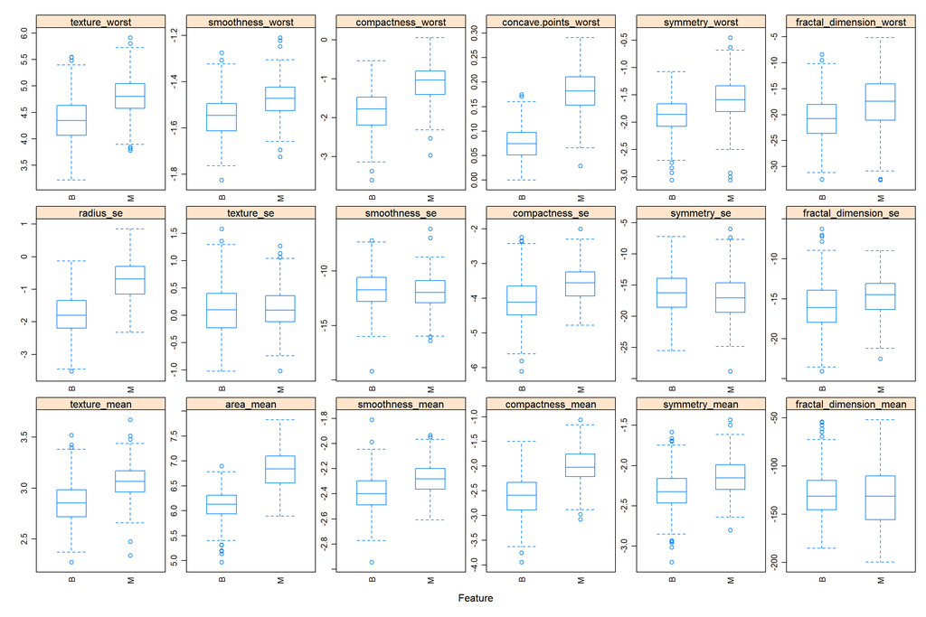

```r
##################################
# Formulating the box plots
##################################
featurePlot(x = DPA.Predictors.Numeric,
            y = DPA$diagnosis,
            plot = "box",
            scales = list(x = list(relation="free", rot = 90),
                          y = list(relation="free")),
            adjust = 1.5,
            pch = "|",
            layout = c(6, 3))
```

```r
##################################
# Obtaining the AUROC
##################################
AUROC <- filterVarImp(x = DPA.Predictors.Numeric,
                        y = DPA$diagnosis)

##################################
# Formulating the summary table
##################################
AUROC_Summary <- AUROC

AUROC_Summary$Predictor <- rownames(AUROC)
names(AUROC_Summary)[1] <- "AUROC"
AUROC_Summary$Metric <- rep("AUROC",nrow(AUROC))

AUROC_Summary[order(AUROC_Summary$AUROC, decreasing=TRUE),]
```

```
##                             AUROC         M               Predictor Metric
## concave.points_worst    0.9667037 0.9667037    concave.points_worst  AUROC
## area_mean               0.9383159 0.9383159               area_mean  AUROC
## radius_se               0.8683341 0.8683341               radius_se  AUROC
## compactness_mean        0.8637823 0.8637823        compactness_mean  AUROC
## compactness_worst       0.8623025 0.8623025       compactness_worst  AUROC
## texture_worst           0.7846308 0.7846308           texture_worst  AUROC
## texture_mean            0.7758245 0.7758245            texture_mean  AUROC
## smoothness_worst        0.7540563 0.7540563        smoothness_worst  AUROC
## symmetry_worst          0.7369391 0.7369391          symmetry_worst  AUROC
## compactness_se          0.7272805 0.7272805          compactness_se  AUROC
## smoothness_mean         0.7220416 0.7220416         smoothness_mean  AUROC
## symmetry_mean           0.6985624 0.6985624           symmetry_mean  AUROC
## fractal_dimension_worst 0.6859706 0.6859706 fractal_dimension_worst  AUROC
## fractal_dimension_se    0.6203028 0.6203028    fractal_dimension_se  AUROC
## symmetry_se             0.5551107 0.5551107             symmetry_se  AUROC
## smoothness_se           0.5311625 0.5311625           smoothness_se  AUROC
## fractal_dimension_mean  0.5154656 0.5154656  fractal_dimension_mean  AUROC
## texture_se              0.5115943 0.5115943              texture_se  AUROC
```

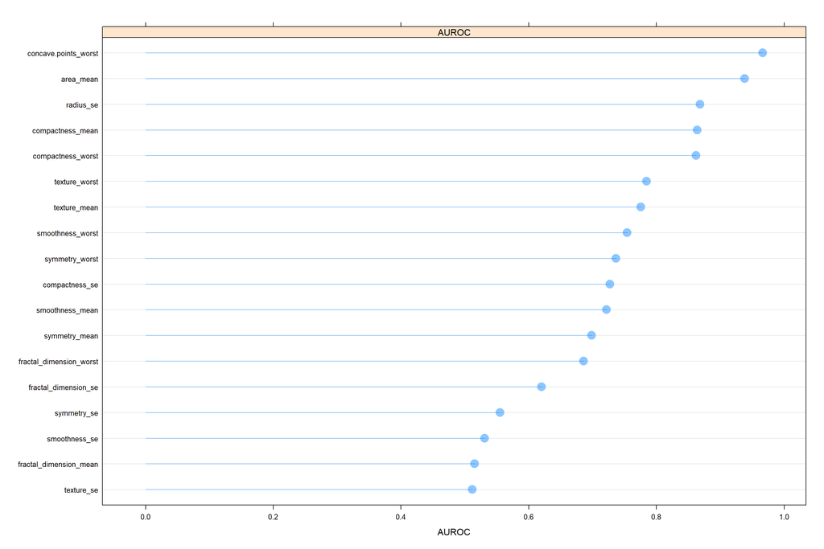

```r
##################################
# Exploring predictor performance
##################################
dotplot(Predictor ~ AUROC | Metric,
        AUROC_Summary,
        origin = 0,
        type = c("p", "h"),
        pch = 16,
        cex = 2,
        alpha = 0.45,
        prepanel = function(x, y) {
            list(ylim = levels(reorder(y, x)))
        },
        panel = function(x, y, ...) {
            panel.dotplot(x, reorder(y, x), ...)
        })
```

```r
##################################
# Creating the pre-modelling dataset
# into the train and test sets
##################################
DPA <- DPA[,colnames(DPA) %in% c("diagnosis",
                                 "texture_worst",
                                 "texture_mean",
                                 "smoothness_worst",
                                 "symmetry_worst",
                                 "compactness_se",
                                 "smoothness_mean")]
set.seed(12345678)
MA_Train_Index  <- createDataPartition(DPA$diagnosis,p=0.8)[[1]]
MA_Train        <- DPA[ MA_Train_Index, ]
MA_Test         <- DPA[-MA_Train_Index, ]
```

## 1.6 Model Bagging

### 1.6.1 Random Forest (MBG_RF)

**Code Chunk | Output**

```r
##################################
# Setting the cross validation process
# using the Repeated K-Fold
##################################
set.seed(12345678)
RKFold_Control <- trainControl(method="repeatedcv",
                              summaryFunction = twoClassSummary,
                              number=5,
                              repeats=5,
                              classProbs = TRUE)

##################################
# Setting the conditions
# for hyperparameter tuning
##################################
RF_Grid = data.frame(mtry = c(25,75,125))

##################################
# Running the random forest model
# by setting the caret method to 'rf'
##################################
set.seed(12345678)
MBG_RF_Tune <- train(x = MA_Train[,!names(MA_Train) %in% c("diagnosis")],
                 y = MA_Train$diagnosis,
                 method = "rf",
                 tuneGrid = RF_Grid,
                 metric = "ROC",
                 trControl = RKFold_Control)

##################################
# Reporting the cross-validation results
# for the train set
##################################
MBG_RF_Tune
```

```
## Random Forest
##
## 912 samples
##   6 predictor
##   2 classes: 'B', 'M'
##
## No pre-processing
## Resampling: Cross-Validated (5 fold, repeated 5 times)
## Summary of sample sizes: 729, 729, 730, 730, 730, 730, ...
## Resampling results across tuning parameters:
##
##   mtry  ROC        Sens       Spec
##    25   0.9661122  0.9527994  0.8988235
##    75   0.9658920  0.9538459  0.9000000
##   125   0.9666119  0.9524424  0.8976471
##
## ROC was used to select the optimal model using the largest value.
## The final value used for the model was mtry = 125.
```

```r
MBG_RF_Tune$finalModel
```

```
##
## Call:
##  randomForest(x = x, y = y, mtry = param$mtry)
##                Type of random forest: classification
##                      Number of trees: 500
## No. of variables tried at each split: 6
##
##         OOB estimate of  error rate: 3.51%
## Confusion matrix:
##     B   M class.error
## B 559  13  0.02272727
## M  19 321  0.05588235
```

```r
MBG_RF_Tune$results
```

```
##   mtry       ROC      Sens      Spec      ROCSD     SensSD     SpecSD
## 1   25 0.9661122 0.9527994 0.8988235 0.02025444 0.02281725 0.04598186
## 2   75 0.9658920 0.9538459 0.9000000 0.02054739 0.02024918 0.04572245
## 3  125 0.9666119 0.9524424 0.8976471 0.02036131 0.02339695 0.04581695
```

```r
(MBG_RF_Train_ROCCurveAUC <- MBG_RF_Tune$results[MBG_RF_Tune$results$mtry==MBG_RF_Tune$bestTune$mtry,
                                                 c("ROC")])
```

```
## [1] 0.9666119
```

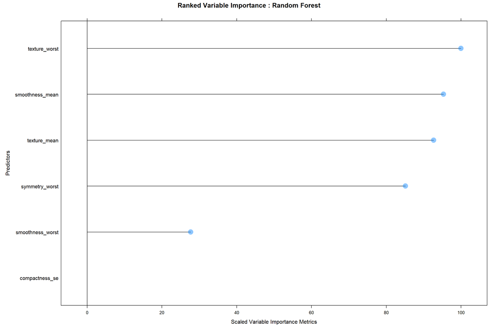

```r
##################################
# Identifying and plotting the
# best model predictors
##################################
MBG_RF_VarImp <- varImp(MBG_RF_Tune, scale = TRUE)
plot(MBG_RF_VarImp,
     top=6,
     scales=list(y=list(cex = .95)),
     main="Ranked Variable Importance : Random Forest",
     xlab="Scaled Variable Importance Metrics",
     ylab="Predictors",
     cex=2,
     origin=0,
     alpha=0.45)
```

```r
##################################
# Independently evaluating the model
# on the test set
##################################
MBG_RF_Test <- data.frame(MBG_RF_Test_Observed = MA_Test$diagnosis,
                          MBG_RF_Test_Predicted = predict(MBG_RF_Tune,
                                                          MA_Test[,!names(MA_Test) %in% c("diagnosis")],
                                                          type = "prob"))

##################################
# Reporting the independent evaluation results
# for the test set
##################################
MBG_RF_Test_ROC <- roc(response = MBG_RF_Test$MBG_RF_Test_Observed,
                       predictor = MBG_RF_Test$MBG_RF_Test_Predicted.M,
                       levels = rev(levels(MBG_RF_Test$MBG_RF_Test_Observed)))

(MBG_RF_Test_AUROC <- auc(MBG_RF_Test_ROC)[1])
```

```
## [1] 0.9875922
```

### 1.6.2 Bagged Classification and Regression Trees (MBG_BTREE)

**Code Chunk | Output**

```r
##################################
# Setting the conditions
# for hyperparameter tuning
##################################
# No hyperparameter tuning process required

##################################
# Running the bagged CART model
# by setting the caret method to 'treebag'
##################################
set.seed(12345678)
MBG_BTREE_Tune <- train(x = MA_Train[,!names(MA_Train) %in% c("diagnosis")],
                        y = MA_Train$diagnosis,
                        method = "treebag",
                        nbagg = 50,
                        metric = "ROC",
                        trControl = RKFold_Control)

##################################
# Reporting the cross-validation results
# for the train set
##################################
MBG_BTREE_Tune
```

```
## Bagged CART
##
## 912 samples
##   6 predictor
##   2 classes: 'B', 'M'
##
## No pre-processing
## Resampling: Cross-Validated (5 fold, repeated 5 times)
## Summary of sample sizes: 729, 729, 730, 730, 730, 730, ...
## Resampling results:
##
##   ROC        Sens       Spec
##   0.9644432  0.9541998  0.9
```

```r
MBG_BTREE_Tune$finalModel
```

```
##
## Bagging classification trees with 50 bootstrap replications
```

```r
MBG_BTREE_Tune$results
```

```
##   parameter       ROC      Sens Spec      ROCSD     SensSD     SpecSD
## 1      none 0.9644432 0.9541998  0.9 0.02096563 0.02170402 0.04452427
```

```r
(MBG_BTREE_Train_ROCCurveAUC <- MBG_BTREE_Tune$results$ROC)
```

```
## [1] 0.9644432
```

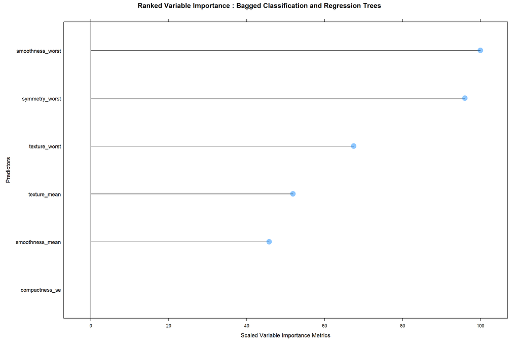

```r
##################################
# Identifying and plotting the
# best model predictors
##################################
MBG_BTREE_VarImp <- varImp(MBG_BTREE_Tune, scale = TRUE)
plot(MBG_BTREE_VarImp,
     top=6,
     scales=list(y=list(cex = .95)),
     main="Ranked Variable Importance : Bagged Classification and Regression Trees",
     xlab="Scaled Variable Importance Metrics",
     ylab="Predictors",
     cex=2,
     origin=0,
     alpha=0.45)
```

```r
##################################
# Independently evaluating the model
# on the test set
##################################
MBG_BTREE_Test <- data.frame(MBG_BTREE_Test_Observed = MA_Test$diagnosis,
                             MBG_BTREE_Test_Predicted = predict(MBG_BTREE_Tune,
                                                                MA_Test[,!names(MA_Test) %in% c("diagnosis")],
                                                                type = "prob"))

##################################
# Reporting the independent evaluation results
# for the test set
##################################
MBG_BTREE_Test_ROC <- roc(response = MBG_BTREE_Test$MBG_BTREE_Test_Observed,
                          predictor = MBG_BTREE_Test$MBG_BTREE_Test_Predicted.M,
                          levels = rev(levels(MBG_BTREE_Test$MBG_BTREE_Test_Observed)))

(MBG_BTREE_Test_AUROC <- auc(MBG_BTREE_Test_ROC)[1])
```

```
## [1] 0.9858317
```

## 1.7 Model Stacking

### 1.7.1 Base Learner Model Development using Linear Discriminant Analysis (BAL_LDA)

**Code Chunk | Output**

```r
##################################
# Setting the conditions
# for hyperparameter tuning
##################################
# No hyperparameter tuning process required

##################################
# Running the linear discriminant analysis model
# by setting the caret method to 'lda'
##################################
set.seed(12345678)
BAL_LDA_Tune <- train(x = MA_Train[,!names(MA_Train) %in% c("diagnosis")],
                        y = MA_Train$diagnosis,
                        method = "lda",
                        preProc = c("center","scale"),
                        metric = "ROC",
                        trControl = RKFold_Control)

##################################
# Reporting the cross-validation results
# for the train set
##################################
BAL_LDA_Tune
```

```
## Linear Discriminant Analysis
##
## 912 samples
##   6 predictor
##   2 classes: 'B', 'M'
##
## Pre-processing: centered (6), scaled (6)
## Resampling: Cross-Validated (5 fold, repeated 5 times)
## Summary of sample sizes: 729, 729, 730, 730, 730, 730, ...
## Resampling results:
##
##   ROC        Sens       Spec
##   0.8762815  0.8720214  0.7105882
```

```r
BAL_LDA_Tune$finalModel
```

```
## Call:
## lda(x, y)
##
## Prior probabilities of groups:
##        B        M
## 0.627193 0.372807
##
## Group means:
##   texture_mean smoothness_mean compactness_se texture_worst smoothness_worst
## B   -0.3194390      -0.2990245     -0.2777306    -0.3459548       -0.3280838
## M    0.5374091       0.5030648      0.4672410     0.5820181        0.5519528
##   symmetry_worst
## B     -0.2957632
## M      0.4975782
##
## Coefficients of linear discriminants:
##                        LD1
## texture_mean     0.4986787
## smoothness_mean  0.3218366
## compactness_se   0.2495221
## texture_worst    0.2741160
## smoothness_worst 0.2408554
## symmetry_worst   0.3784915
```

```r
BAL_LDA_Tune$results
```

```
##   parameter       ROC      Sens      Spec      ROCSD     SensSD     SpecSD
## 1      none 0.8762815 0.8720214 0.7105882 0.02587517 0.02739545 0.05331432
```

```r
(BAL_LDA_Train_ROCCurveAUC <- BAL_LDA_Tune$results$ROC)
```

```
## [1] 0.8762815
```

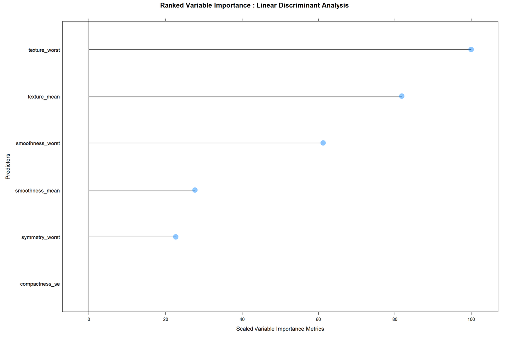

```r
##################################
# Identifying and plotting the
# best model predictors
##################################
BAL_LDA_VarImp <- varImp(BAL_LDA_Tune, scale = TRUE)
plot(BAL_LDA_VarImp,
     top=6,
     scales=list(y=list(cex = .95)),
     main="Ranked Variable Importance : Linear Discriminant Analysis",
     xlab="Scaled Variable Importance Metrics",
     ylab="Predictors",
     cex=2,
     origin=0,
     alpha=0.45)
```

```r
##################################
# Independently evaluating the model
# on the test set
##################################
BAL_LDA_Test <- data.frame(BAL_LDA_Test_Observed = MA_Test$diagnosis,
                           BAL_LDA_Test_Predicted = predict(BAL_LDA_Tune,
                                                            MA_Test[,!names(MA_Test) %in% c("diagnosis")],
                                                            type = "prob"))

##################################
# Reporting the independent evaluation results
# for the test set
##################################
BAL_LDA_Test_ROC <- roc(response = BAL_LDA_Test$BAL_LDA_Test_Observed,
                        predictor = BAL_LDA_Test$BAL_LDA_Test_Predicted.M,
                        levels = rev(levels(BAL_LDA_Test$BAL_LDA_Test_Observed)))

(BAL_LDA_Test_AUROC <- auc(BAL_LDA_Test_ROC)[1])
```

```
## [1] 0.88833
```

### 1.7.2 Base Learner Model Development using Classification and Regression Trees (BAL_CART)

**Code Chunk | Output**

```r
##################################
# Setting the conditions
# for hyperparameter tuning
##################################
CART_Grid = data.frame(cp = c(0.001, 0.005, 0.010, 0.015, 0.020))

##################################
# Running the classification and regression tree model
# by setting the caret method to 'rpart'
##################################
set.seed(12345678)
BAL_CART_Tune <- train(x = MA_Train[,!names(MA_Train) %in% c("diagnosis")],
                       y = MA_Train$diagnosis,
                       method = "rpart",
                       tuneGrid = CART_Grid,
                       metric = "ROC",
                       trControl = RKFold_Control)

##################################
# Reporting the cross-validation results
# for the train set
##################################
BAL_CART_Tune
```

```
## CART
##
## 912 samples
##   6 predictor
##   2 classes: 'B', 'M'
##
## No pre-processing
## Resampling: Cross-Validated (5 fold, repeated 5 times)
## Summary of sample sizes: 729, 729, 730, 730, 730, 730, ...
## Resampling results across tuning parameters:
##
##   cp     ROC        Sens       Spec
##   0.001  0.8614523  0.8503158  0.7482353
##   0.005  0.8512807  0.8640061  0.7452941
##   0.010  0.8297650  0.8702944  0.7211765
##   0.015  0.8139619  0.8608299  0.7170588
##   0.020  0.8094478  0.8552677  0.7164706
##
## ROC was used to select the optimal model using the largest value.
## The final value used for the model was cp = 0.001.
```

```r
BAL_CART_Tune$finalModel
```

```
## n= 912
##
## node), split, n, loss, yval, (yprob)
##       * denotes terminal node
##
##    1) root 912 340 B (0.62719298 0.37280702)
##      2) texture_mean< 2.927988 437  67 B (0.84668192 0.15331808)
##        4) symmetry_worst< -1.34686 398  38 B (0.90452261 0.09547739)
##          8) smoothness_mean< -2.074653 390  33 B (0.91538462 0.08461538)
##           16) texture_mean< 2.711046 134   0 B (1.00000000 0.00000000) *
##           17) texture_mean>=2.711046 256  33 B (0.87109375 0.12890625)
##             34) symmetry_worst< -1.427209 247  28 B (0.88663968 0.11336032)
##               68) smoothness_mean< -2.468758 62   0 B (1.00000000 0.00000000) *
##               69) smoothness_mean>=-2.468758 185  28 B (0.84864865 0.15135135)
##                138) smoothness_mean>=-2.28574 59   3 B (0.94915254 0.05084746) *
##                139) smoothness_mean< -2.28574 126  25 B (0.80158730 0.19841270)
##                  278) compactness_se< -4.691273 24   0 B (1.00000000 0.00000000) *
##                  279) compactness_se>=-4.691273 102  25 B (0.75490196 0.24509804)
##                    558) smoothness_mean< -2.296604 94  20 B (0.78723404 0.21276596)
##                     1116) compactness_se>=-4.479607 81  14 B (0.82716049 0.17283951)
##                       2232) smoothness_worst< -1.472892 73  10 B (0.86301370 0.13698630)
##                         4464) symmetry_worst>=-1.749307 28   0 B (1.00000000 0.00000000) *
##                         4465) symmetry_worst< -1.749307 45  10 B (0.77777778 0.22222222)
##                           8930) symmetry_worst< -1.841614 34   2 B (0.94117647 0.05882353) *
##                           8931) symmetry_worst>=-1.841614 11   3 M (0.27272727 0.72727273) *
##                       2233) smoothness_worst>=-1.472892 8   4 B (0.50000000 0.50000000) *
##                     1117) compactness_se< -4.479607 13   6 B (0.53846154 0.46153846) *
##                    559) smoothness_mean>=-2.296604 8   3 M (0.37500000 0.62500000) *
##             35) symmetry_worst>=-1.427209 9   4 M (0.44444444 0.55555556) *
##          9) smoothness_mean>=-2.074653 8   3 M (0.37500000 0.62500000) *
##        5) symmetry_worst>=-1.34686 39  10 M (0.25641026 0.74358974)
##         10) smoothness_mean< -2.32364 7   1 B (0.85714286 0.14285714) *
##         11) smoothness_mean>=-2.32364 32   4 M (0.12500000 0.87500000) *
##      3) texture_mean>=2.927988 475 202 M (0.42526316 0.57473684)
##        6) smoothness_mean< -2.425205 140  29 B (0.79285714 0.20714286)
##         12) symmetry_worst< -1.496954 133  23 B (0.82706767 0.17293233)
##           24) smoothness_worst< -1.60101 85   8 B (0.90588235 0.09411765)
##             48) texture_mean>=2.980363 64   3 B (0.95312500 0.04687500) *
##             49) texture_mean< 2.980363 21   5 B (0.76190476 0.23809524)
##               98) symmetry_worst< -1.919875 12   0 B (1.00000000 0.00000000) *
```

[output cut: 23 more lines]

```
##                243) symmetry_worst>=-2.207988 26   3 M (0.11538462 0.88461538) *
##             61) compactness_se>=-3.02233 13   0 M (0.00000000 1.00000000) *
##           31) symmetry_worst>=-1.776275 215  30 M (0.13953488 0.86046512)
##             62) compactness_se< -4.040144 38  16 M (0.42105263 0.57894737)
##              124) smoothness_mean>=-2.294648 15   2 B (0.86666667 0.13333333) *
##              125) smoothness_mean< -2.294648 23   3 M (0.13043478 0.86956522) *
##             63) compactness_se>=-4.040144 177  14 M (0.07909605 0.92090395)
##              126) smoothness_mean< -2.32432 37   9 M (0.24324324 0.75675676) *
##              127) smoothness_mean>=-2.32432 140   5 M (0.03571429 0.96428571)
##                254) texture_worst< 4.824228 54   5 M (0.09259259 0.90740741)
##                  508) compactness_se< -3.447524 24   5 M (0.20833333 0.79166667)
##                   1016) texture_worst>=4.608306 8   3 B (0.62500000 0.37500000) *
##                   1017) texture_worst< 4.608306 16   0 M (0.00000000 1.00000000) *
##                  509) compactness_se>=-3.447524 30   0 M (0.00000000 1.00000000) *
##                255) texture_worst>=4.824228 86   0 M (0.00000000 1.00000000) *
```

```r
BAL_CART_Tune$results
```

```
##      cp       ROC      Sens      Spec      ROCSD     SensSD     SpecSD
## 1 0.001 0.8614523 0.8503158 0.7482353 0.03685507 0.04170440 0.06635597
## 2 0.005 0.8512807 0.8640061 0.7452941 0.03662151 0.02767361 0.05816420
## 3 0.010 0.8297650 0.8702944 0.7211765 0.04245561 0.03675966 0.07705751
## 4 0.015 0.8139619 0.8608299 0.7170588 0.04009017 0.04021240 0.07056270
## 5 0.020 0.8094478 0.8552677 0.7164706 0.04150844 0.03315895 0.06891397
```

```r
(BAL_CART_Train_ROCCurveAUC <- BAL_CART_Tune$results[BAL_CART_Tune$results$cp==BAL_CART_Tune$bestTune$cp,
                                                     c("ROC")])
```

```
## [1] 0.8614523
```

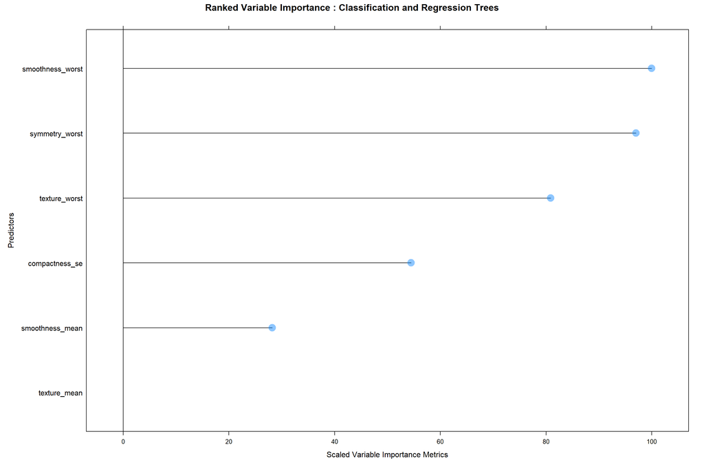

```r
##################################
# Identifying and plotting the
# best model predictors
##################################
BAL_CART_VarImp <- varImp(BAL_CART_Tune, scale = TRUE)
plot(BAL_CART_VarImp,
     top=6,
     scales=list(y=list(cex = .95)),
     main="Ranked Variable Importance : Classification and Regression Trees",
     xlab="Scaled Variable Importance Metrics",
     ylab="Predictors",
     cex=2,
     origin=0,
     alpha=0.45)
```

```r
##################################
# Independently evaluating the model
# on the test set
##################################
BAL_CART_Test <- data.frame(BAL_CART_Test_Observed = MA_Test$diagnosis,
                            BAL_CART_Test_Predicted = predict(BAL_CART_Tune,
                                                              MA_Test[,!names(MA_Test) %in% c("diagnosis")],
                                                              type = "prob"))

##################################
# Reporting the independent evaluation results
# for the test set
##################################
BAL_CART_Test_ROC <- roc(response = BAL_CART_Test$BAL_CART_Test_Observed,
                         predictor = BAL_CART_Test$BAL_CART_Test_Predicted.M,
                         levels = rev(levels(BAL_CART_Test$BAL_CART_Test_Observed)))

(BAL_CART_Test_AUROC <- auc(BAL_CART_Test_ROC)[1])
```

```
## [1] 0.9210681
```

### 1.7.3 Base Learner Model Development using Support Vector Machine - Radial Basis Function Kernel (BAL_SVM_R)

**Code Chunk | Output**

```r
##################################
# Setting the conditions
# for hyperparameter tuning
##################################
# used a range of default values

##################################
# Running the support vector machine model
# by setting the caret method to 'svmRadial'
##################################
set.seed(12345678)
BAL_SVM_R_Tune <- train(x = MA_Train[,!names(MA_Train) %in% c("diagnosis")],
                        y = MA_Train$diagnosis,
                        method = "svmRadial",
                        preProc = c("center", "scale"),
                        tuneLength = 14,
                        metric = "ROC",
                        trControl = RKFold_Control)

##################################
# Reporting the cross-validation results
# for the train set
##################################
BAL_SVM_R_Tune
```

```
## Support Vector Machines with Radial Basis Function Kernel
##
## 912 samples
##   6 predictor
##   2 classes: 'B', 'M'
##
## Pre-processing: centered (6), scaled (6)
## Resampling: Cross-Validated (5 fold, repeated 5 times)
## Summary of sample sizes: 729, 729, 730, 730, 730, 730, ...
## Resampling results across tuning parameters:
##
##   C        ROC        Sens       Spec
##      0.25  0.8792747  0.8964943  0.7005882
##      0.50  0.8828520  0.8964851  0.7064706
##      1.00  0.8853296  0.8961373  0.7064706
##      2.00  0.8879393  0.8958017  0.7164706
##      4.00  0.8909259  0.8937056  0.7241176
##      8.00  0.8960321  0.9003417  0.7300000
##     16.00  0.8967388  0.9052235  0.7264706
##     32.00  0.8982511  0.9059283  0.7347059
##     64.00  0.9005909  0.9135957  0.7482353
##    128.00  0.9039633  0.9233837  0.7552941
##    256.00  0.9090738  0.9374005  0.7652941
##    512.00  0.9090150  0.9412387  0.7782353
##   1024.00  0.9077637  0.9387643  0.7900000
##   2048.00  0.9097712  0.9436857  0.7976471
##
## Tuning parameter 'sigma' was held constant at a value of 0.1790538
## ROC was used to select the optimal model using the largest value.
## The final values used for the model were sigma = 0.1790538 and C = 2048.
```

```r
BAL_SVM_R_Tune$finalModel
```

```
## Support Vector Machine object of class "ksvm"
##
## SV type: C-svc  (classification)
##  parameter : cost C = 2048
##
## Gaussian Radial Basis kernel function.
##  Hyperparameter : sigma =  0.179053781320727
##
## Number of Support Vectors : 302
##
## Objective Function Value : -123343.3
## Training error : 0.013158
## Probability model included.
```

```r
BAL_SVM_R_Tune$results
```

```
##        sigma       C       ROC      Sens      Spec      ROCSD     SensSD
## 1  0.1790538    0.25 0.8792747 0.8964943 0.7005882 0.02548830 0.02322464
## 2  0.1790538    0.50 0.8828520 0.8964851 0.7064706 0.02410960 0.02143187
## 3  0.1790538    1.00 0.8853296 0.8961373 0.7064706 0.02490232 0.02237023
## 4  0.1790538    2.00 0.8879393 0.8958017 0.7164706 0.02417564 0.02120909
## 5  0.1790538    4.00 0.8909259 0.8937056 0.7241176 0.02144916 0.02499684
## 6  0.1790538    8.00 0.8960321 0.9003417 0.7300000 0.02035456 0.02715491
## 7  0.1790538   16.00 0.8967388 0.9052235 0.7264706 0.01882154 0.02634028
## 8  0.1790538   32.00 0.8982511 0.9059283 0.7347059 0.01957743 0.02468638
## 9  0.1790538   64.00 0.9005909 0.9135957 0.7482353 0.02224693 0.02746024
## 10 0.1790538  128.00 0.9039633 0.9233837 0.7552941 0.02309492 0.02966385
## 11 0.1790538  256.00 0.9090738 0.9374005 0.7652941 0.02327350 0.03080847
## 12 0.1790538  512.00 0.9090150 0.9412387 0.7782353 0.02271246 0.02797556
## 13 0.1790538 1024.00 0.9077637 0.9387643 0.7900000 0.02374909 0.03058368
## 14 0.1790538 2048.00 0.9097712 0.9436857 0.7976471 0.02420238 0.02639300
##        SpecSD
## 1  0.04800669
## 2  0.05031619
## 3  0.05085061
## 4  0.04319292
## 5  0.04864069
## 6  0.04838064
## 7  0.04727280
## 8  0.05766006
## 9  0.05474856
## 10 0.04762981
## 11 0.04793155
## 12 0.04706648
## 13 0.04083366
## 14 0.04272306
```

```r
(BAL_SVM_R_Train_ROCCurveAUC <- BAL_SVM_R_Tune$results[BAL_SVM_R_Tune$results$C==BAL_SVM_R_Tune$bestTune$C,
                                                       c("ROC")])
```

```
## [1] 0.9097712
```

```r
##################################
# Identifying and plotting the
# best model predictors
##################################
# model does not support variable importance measurement

##################################
# Independently evaluating the model
# on the test set
##################################
BAL_SVM_R_Test <- data.frame(BAL_SVM_R_Test_Observed = MA_Test$diagnosis,
                             BAL_SVM_R_Test_Predicted = predict(BAL_SVM_R_Tune,
                                                                MA_Test[,!names(MA_Test) %in% c("diagnosis")],
                                                                type = "prob"))

##################################
# Reporting the independent evaluation results
# for the test set
##################################
BAL_SVM_R_Test_ROC <- roc(response = BAL_SVM_R_Test$BAL_SVM_R_Test_Observed,
                          predictor = BAL_SVM_R_Test$BAL_SVM_R_Test_Predicted.M,
                          levels = rev(levels(BAL_SVM_R_Test$BAL_SVM_R_Test_Observed)))

(BAL_SVM_R_Test_AUROC <- auc(BAL_SVM_R_Test_ROC)[1])
```

```
## [1] 0.9376258
```

### 1.7.4 Base Learner Model Development using K-Nearest Neighbors (BAL_KNN)

**Code Chunk | Output**

```r
##################################
# Setting the conditions
# for hyperparameter tuning
##################################
KNN_Grid = data.frame(k = 1:15)

##################################
# Running the k-nearest neighbors model
# by setting the caret method to 'knn'
##################################
set.seed(12345678)
BAL_KNN_Tune <- train(x = MA_Train[,!names(MA_Train) %in% c("diagnosis")],
                      y = MA_Train$diagnosis,
                      method = "knn",
                      preProc = c("center", "scale"),
                      tuneGrid = KNN_Grid,
                      metric = "ROC",
                      trControl = RKFold_Control)

##################################
# Reporting the cross-validation results
# for the train set
##################################
BAL_KNN_Tune
```

```
## k-Nearest Neighbors
##
## 912 samples
##   6 predictor
##   2 classes: 'B', 'M'
##
## Pre-processing: centered (6), scaled (6)
## Resampling: Cross-Validated (5 fold, repeated 5 times)
## Summary of sample sizes: 729, 729, 730, 730, 730, 730, ...
## Resampling results across tuning parameters:
##
##   k   ROC        Sens       Spec
##    1  0.9076428  0.9205797  0.8947059
##    2  0.8730636  0.8202471  0.7252941
##    3  0.8824422  0.8248574  0.6982353
##    4  0.8818437  0.8643417  0.7288235
##    5  0.8815800  0.8887689  0.7488235
##    6  0.8827032  0.8716644  0.7294118
##    7  0.8848091  0.8730648  0.7211765
##    8  0.8832599  0.8825080  0.7247059
##    9  0.8826004  0.8905416  0.7305882
##   10  0.8821762  0.8839146  0.7129412
##   11  0.8817764  0.8867185  0.7164706
##   12  0.8794329  0.8870664  0.7135294
##   13  0.8785997  0.8860046  0.7123529
##   14  0.8818346  0.8821571  0.7117647
##   15  0.8846281  0.8825263  0.7135294
##
## ROC was used to select the optimal model using the largest value.
## The final value used for the model was k = 1.
```

```r
BAL_KNN_Tune$finalModel
```

```
## 1-nearest neighbor model
## Training set outcome distribution:
##
##   B   M
## 572 340
```

```r
BAL_KNN_Tune$results
```

```
##     k       ROC      Sens      Spec      ROCSD     SensSD     SpecSD
## 1   1 0.9076428 0.9205797 0.8947059 0.02583023 0.02881542 0.04064787
## 2   2 0.8730636 0.8202471 0.7252941 0.02876280 0.04286672 0.05229039
## 3   3 0.8824422 0.8248574 0.6982353 0.02631797 0.03848173 0.05807117
## 4   4 0.8818437 0.8643417 0.7288235 0.02394691 0.03156119 0.04651958
## 5   5 0.8815800 0.8887689 0.7488235 0.01965491 0.03178715 0.03649904
## 6   6 0.8827032 0.8716644 0.7294118 0.02080533 0.03287310 0.04411765
## 7   7 0.8848091 0.8730648 0.7211765 0.01884352 0.02994811 0.04482280
## 8   8 0.8832599 0.8825080 0.7247059 0.02014577 0.03294398 0.04127265
## 9   9 0.8826004 0.8905416 0.7305882 0.01945929 0.03067128 0.03620157
## 10 10 0.8821762 0.8839146 0.7129412 0.02010782 0.02722610 0.04767519
## 11 11 0.8817764 0.8867185 0.7164706 0.02007380 0.02682363 0.04462939
## 12 12 0.8794329 0.8870664 0.7135294 0.02001825 0.03088131 0.04331791
## 13 13 0.8785997 0.8860046 0.7123529 0.02061021 0.03027290 0.04246920
## 14 14 0.8818346 0.8821571 0.7117647 0.02038839 0.02947233 0.04432142
## 15 15 0.8846281 0.8825263 0.7135294 0.02000838 0.02791806 0.05114040
```

```r
(BAL_KNN_Train_ROCCurveAUC <- BAL_KNN_Tune$results[BAL_KNN_Tune$results$k==BAL_KNN_Tune$bestTune$k,
                                                   c("ROC")])
```

```
## [1] 0.9076428
```

```r
##################################
# Identifying and plotting the
# best model predictors
##################################
# model does not support variable importance measurement

##################################
# Independently evaluating the model
# on the test set
##################################
BAL_KNN_Test <- data.frame(BAL_KNN_Test_Observed = MA_Test$diagnosis,
                           BAL_KNN_Test_Predicted = predict(BAL_KNN_Tune,
                                                            MA_Test[,!names(MA_Test) %in% c("diagnosis")],
                                                            type = "prob"))

##################################
# Reporting the independent evaluation results
# for the test set
##################################
BAL_KNN_Test_ROC <- roc(response = BAL_KNN_Test$BAL_KNN_Test_Observed,
                        predictor = BAL_KNN_Test$BAL_KNN_Test_Predicted.M,
                        levels = rev(levels(BAL_KNN_Test$BAL_KNN_Test_Observed)))

(BAL_KNN_Test_AUROC <- auc(BAL_KNN_Test_ROC)[1])
```

```
## [1] 0.9361167
```

### 1.7.5 Base Learner Model Development using Naive Bayes (BAL_NB)

**Code Chunk | Output**

```r
##################################
# Setting the conditions
# for hyperparameter tuning
##################################
NB_Grid = data.frame(usekernel = c(TRUE, FALSE), fL = 2, adjust = FALSE)

##################################
# Running the naive bayes model
# by setting the caret method to 'nb'
##################################
set.seed(12345678)
BAL_NB_Tune <- train(x = MA_Train[,!names(MA_Train) %in% c("diagnosis")],
                     y = MA_Train$diagnosis,
                     method = "nb",
                     tuneGrid = NB_Grid,
                     metric = "ROC",
                     trControl = RKFold_Control)

##################################
# Reporting the cross-validation results
# for the train set
##################################
BAL_NB_Tune
```

```
## Naive Bayes
##
## 912 samples
##   6 predictor
##   2 classes: 'B', 'M'
##
## No pre-processing
## Resampling: Cross-Validated (5 fold, repeated 5 times)
## Summary of sample sizes: 729, 729, 730, 730, 730, 730, ...
## Resampling results across tuning parameters:
##
##   usekernel  ROC        Sens       Spec
##   FALSE      0.8873525  0.8552525  0.7605882
##    TRUE            NaN        NaN        NaN
##
## Tuning parameter 'fL' was held constant at a value of 2
## Tuning
##  parameter 'adjust' was held constant at a value of FALSE
## ROC was used to select the optimal model using the largest value.
## The final values used for the model were fL = 2, usekernel = FALSE and adjust
##  = FALSE.
```

```r
BAL_NB_Tune$finalModel
```

```
## $apriori
## grouping
##        B        M
## 0.627193 0.372807
##
## $tables
## $tables$texture_mean
##       [,1]      [,2]
## B 2.866111 0.2131833
## M 3.054338 0.1756238
##
## $tables$smoothness_mean
##        [,1]      [,2]
## B -2.394224 0.1422449
## M -2.276397 0.1231980
##
## $tables$compactness_se
##        [,1]      [,2]
## B -4.044941 0.6453164
## M -3.559438 0.5400556
##
## $tables$texture_worst
##       [,1]      [,2]
## B 4.374373 0.4270218
## M 4.792405 0.3581525
##
## $tables$smoothness_worst
##        [,1]       [,2]
## B -1.553385 0.08631008
## M -1.469949 0.08502371
##
## $tables$symmetry_worst
##        [,1]      [,2]
## B -1.882256 0.3136605
## M -1.584759 0.3956037
##
##
## $levels
## [1] "B" "M"
##
```

[output cut: 1844 more lines]

```
##
## $tuneValue
##   fL usekernel adjust
## 1  2     FALSE  FALSE
##
## $obsLevels
## [1] "B" "M"
## attr(,"ordered")
## [1] FALSE
##
## $param
## list()
##
## attr(,"class")
## [1] "NaiveBayes"
```

```r
BAL_NB_Tune$results
```

```
##   usekernel fL adjust       ROC      Sens      Spec      ROCSD     SensSD
## 1     FALSE  2  FALSE 0.8873525 0.8552525 0.7605882 0.02125535 0.03336686
## 2      TRUE  2  FALSE       NaN       NaN       NaN         NA         NA
##       SpecSD
## 1 0.04679768
## 2         NA
```

```r
(BAL_NB_Train_ROCCurveAUC <- BAL_NB_Tune$results[BAL_NB_Tune$results$usekernel==BAL_NB_Tune$bestTune$usekernel &
                                                 BAL_NB_Tune$results$adjust==BAL_NB_Tune$bestTune$adjust,
                                                 c("ROC")])
```

```
## [1] 0.8873525
```

```r
##################################
# Identifying and plotting the
# best model predictors
##################################
# model does not support variable importance measurement

##################################
# Independently evaluating the model
# on the test set
##################################
BAL_NB_Test <- data.frame(BAL_NB_Test_Observed = MA_Test$diagnosis,
                          BAL_NB_Test_Predicted = predict(BAL_NB_Tune,
                                                          MA_Test[,!names(MA_Test) %in% c("diagnosis")],
                                                          type = "prob"))

##################################
# Reporting the independent evaluation results
# for the test set
##################################
BAL_NB_Test_ROC <- roc(response = BAL_NB_Test$BAL_NB_Test_Observed,
                       predictor = BAL_NB_Test$BAL_NB_Test_Predicted.M,
                       levels = rev(levels(BAL_NB_Test$BAL_NB_Test_Observed)))

(BAL_NB_Test_AUROC <- auc(BAL_NB_Test_ROC)[1])
```

```
## [1] 0.8969651
```

## 1.8 Algorithm Comparison Summary

**Code Chunk | Output**

```r
##################################
# Consolidating the resampling results
# for the formulated models
##################################
(Consolidated_Resampling <- resamples(list(MBG_RF = MBG_RF_Tune,
                                           MBG_BTREE = MBG_BTREE_Tune,
                                           BAL_LDA = BAL_LDA_Tune,
                                           BAL_CART = BAL_CART_Tune,
                                           BAL_KNN = BAL_KNN_Tune,
                                           BAL_NB = BAL_NB_Tune)))
```

```
##
## Call:
## resamples.default(x = list(MBG_RF = MBG_RF_Tune, MBG_BTREE =
##  MBG_BTREE_Tune, BAL_LDA = BAL_LDA_Tune, BAL_CART = BAL_CART_Tune, BAL_KNN
##  = BAL_KNN_Tune, BAL_NB = BAL_NB_Tune))
##
## Models: MBG_RF, MBG_BTREE, BAL_LDA, BAL_CART, BAL_KNN, BAL_NB
## Number of resamples: 25
## Performance metrics: ROC, Sens, Spec
## Time estimates for: everything, final model fit
```

```r
summary(Consolidated_Resampling)
```

```
##
## Call:
## summary.resamples(object = Consolidated_Resampling)
##
## Models: MBG_RF, MBG_BTREE, BAL_LDA, BAL_CART, BAL_KNN, BAL_NB
## Number of resamples: 25
##
## ROC
##                Min.   1st Qu.    Median      Mean   3rd Qu.      Max. NA's
## MBG_RF    0.9210526 0.9502709 0.9748721 0.9666119 0.9805627 0.9911125    0
## MBG_BTREE 0.9224071 0.9521100 0.9696852 0.9644432 0.9808437 0.9901535    0
## BAL_LDA   0.8102302 0.8641641 0.8828689 0.8762815 0.8913829 0.9296675    0
## BAL_CART  0.7863777 0.8392673 0.8597187 0.8614523 0.8853844 0.9405371    0
## BAL_KNN   0.8342363 0.8946931 0.9120227 0.9076428 0.9237616 0.9562020    0
## BAL_NB    0.8354220 0.8777090 0.8886189 0.8873525 0.8989938 0.9317136    0
##
## Sens
##                Min.   1st Qu.    Median      Mean   3rd Qu.      Max. NA's
## MBG_RF    0.8956522 0.9473684 0.9478261 0.9524424 0.9736842 0.9913043    0
## MBG_BTREE 0.8956522 0.9473684 0.9561404 0.9541998 0.9736842 0.9913043    0
## BAL_LDA   0.8260870 0.8508772 0.8684211 0.8720214 0.8947368 0.9304348    0
## BAL_CART  0.7631579 0.8086957 0.8596491 0.8503158 0.8859649 0.9043478    0
## BAL_KNN   0.8596491 0.9035088 0.9210526 0.9205797 0.9391304 0.9736842    0
## BAL_NB    0.7913043 0.8333333 0.8596491 0.8552525 0.8771930 0.9130435    0
##
## Spec
##                Min.   1st Qu.    Median      Mean   3rd Qu.      Max. NA's
## MBG_RF    0.7941176 0.8676471 0.8970588 0.8976471 0.9411765 0.9852941    0
## MBG_BTREE 0.8235294 0.8676471 0.9117647 0.9000000 0.9264706 0.9852941    0
## BAL_LDA   0.6323529 0.6764706 0.7058824 0.7105882 0.7352941 0.8235294    0
## BAL_CART  0.5588235 0.7058824 0.7500000 0.7482353 0.7794118 0.8823529    0
## BAL_KNN   0.8088235 0.8676471 0.8970588 0.8947059 0.9264706 0.9558824    0
## BAL_NB    0.6911765 0.7205882 0.7500000 0.7605882 0.7794118 0.8529412    0
```

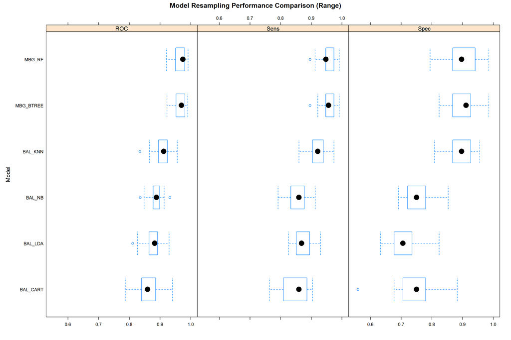

```r
##################################
# Exploring the resampling results
##################################
bwplot(Consolidated_Resampling,
       main = "Model Resampling Performance Comparison (Range)",
       ylab = "Model",
       pch=16,
       cex=2,
       layout=c(3,1))
```

# **2. References**

**[Book]** [Applied Predictive Modeling](http://appliedpredictivemodeling.com/) by Max Kuhn and Kjell Johnson  
**[Book]** [An Introduction to Statistical Learning](https://www.statlearning.com/) by Gareth James, Daniela Witten, Trevor Hastie and Rob Tibshirani  
**[Book]** [Multivariate Data Visualization with R](http://lmdvr.r-forge.r-project.org/figures/figures.html) by Deepayan Sarkar  
**[Book]** [Machine Learning](https://bookdown.org/ssjackson300/Machine-Learning-Lecture-Notes/) by Samuel Jackson  
**[Book]** [Data Modeling Methods](https://bookdown.org/larget_jacob/data-modeling-methods/) by Jacob Larget  
**[Book]** [Introduction to R and Statistics](https://saestatsteaching.tech/) by University of Western Australia  
**[Book]** [Feature Engineering and Selection: A Practical Approach for Predictive Models](http://www.feat.engineering/index.html) by Max Kuhn and Kjell Johnson  
**[Book]** [Introduction to Research Methods](https://bookdown.org/ejvanholm/Textbook/) by Eric van Holm  
**[R Package]** [AppliedPredictiveModeling](https://cran.r-project.org/web//packages/AppliedPredictiveModeling/AppliedPredictiveModeling.pdf) by Max Kuhn  
**[R Package]** [caret](https://topepo.github.io/caret/index.html) by Max Kuhn  
**[R Package]** [rpart](https://mran.microsoft.com/web/packages/rpart/rpart.pdf) by Terry Therneau and Beth Atkinson  
**[R Package]** [lattice](https://cran.r-project.org/web/packages/lattice/lattice.pdf) by Deepayan Sarkar  
**[R Package]** [dplyr](https://cran.r-project.org/web/packages/dplyr/index.html/) by Hadley Wickham  
**[R Package]** [tidyr](https://cran.r-project.org/web/packages/tidyr/tidyr.pdf) by Hadley Wickham  
**[R Package]** [moments](https://cran.r-project.org/web/packages/moments/index.html) by Lukasz Komsta and Frederick  
**[R Package]** [skimr](https://cran.r-project.org/web/packages/skimr/skimr.pdf) by Elin Waring  
**[R Package]** [RANN](https://cran.r-project.org/web/packages/RANN/RANN.pdf) by Sunil Arya, David Mount, Samuel Kemp and Gregory Jefferis  
**[R Package]** [corrplot](https://cran.r-project.org/web/packages/corrplot/corrplot.pdf) by Taiyun Wei  
**[R Package]** [tidyverse](https://cran.r-project.org/web/packages/tidyverse/tidyverse.pdf) by Hadley Wickham  
**[R Package]** [lares](https://cran.rstudio.com/web/packages/lares/lares.pdf) by Bernardo Lares  
**[R Package]** [DMwR](https://mran.microsoft.com/snapshot/2016-05-02/web/packages/DMwR/DMwR.pdf) by Luis Torgo  
**[R Package]** [gridExtra](https://cran.r-project.org/web/packages/gridExtra/gridExtra.pdf) by Baptiste Auguie and Anton Antonov  
**[R Package]** [rattle](https://cran.r-project.org/web/packages/rattle/rattle.pdf) by Graham Williams  
**[R Package]** [RColorBrewer](https://cran.r-project.org/web//packages/RColorBrewer/RColorBrewer.pdf) by Erich Neuwirth  
**[R Package]** [stats](https://search.r-project.org/R/refmans/stats/html/00Index.html) by R Core Team

**[R Package]** [caretEnsemble](https://cran.r-project.org/web/packages/caretEnsemble/caretEnsemble.pdf) by Zachary Deane-Mayer  
**[Article]** [A Brief Introduction to caretEnsemble)](https://cran.r-project.org/web/packages/caretEnsemble/vignettes/caretEnsemble-intro.html) by Zachary Deane-Mayer  
**[Article]** [How to Build an Ensemble Of Machine Learning Algorithms in R](https://machinelearningmastery.com/machine-learning-ensembles-with-r/) by Jason Brownlee  
**[Article]** [Ensemble Learning: Bagging, Boosting, and Stacking](https://towardsai.net/p/machine-learning/ensemble-learning-bagging-boosting-and-stacking) by Towards AI Team  
**[Article]** [Bagging, Boosting, and Stacking in Machine Learning](https://www.baeldung.com/cs/bagging-boosting-stacking-ml-ensemble-models) by Emmanuella Budu  
**[Article]** [Stacking Ensemble Machine Learning With Python](https://machinelearningmastery.com/stacking-ensemble-machine-learning-with-python/) by Jason Brownlee  
**[Article]** [Essence of Boosting Ensembles for Machine Learning](https://machinelearningmastery.com/essence-of-boosting-ensembles-for-machine-learning/) by Jason Brownlee  
**[Article]** [Ensemble Modeling with R](https://www.pluralsight.com/guides/ensemble-modeling-with-r) by Deepika Singh  
**[Article]** [Creating Ensemble Models in R](https://dustinrogers.github.io/Ensemble-Models/) by Dustin Rogers  
**[Publication]** [Ensemble Selection from Libraries of Models](https://citeseerx.ist.psu.edu/viewdoc/download?doi=10.1.1.60.2859&rep=rep1&type=pdf) by Rich Caruana, Alexandru Niculescu-Mizil, Geoff Crew and Alex Ksikes (Proceedings of the 21 st International Conference on Machine Learning,)  
**[Course]** [Applied Data Mining and Statistical Learning](https://online.stat.psu.edu/stat508/) by Penn State Eberly College of Science